# Preparation

## 实验介绍

### 1.实验内容

本实验包括:

- 熟悉课程平台Jupyter实验环境
- 使用Matplotlib创建散点图

### 2.实验目标

通过实验熟悉课程平台环境，掌握Jupyter的基础操作

### 3.实验环境

- python 3.6.5
- numpy 1.13.3
- matplotlib 2.2.3

### 实验准备

点击屏幕右上方的下载实验数据模块，选择下载kNN_Dating.tgz到指定目录下，然后再依次选择点击上方的File->Open->Upload,上传刚才下载的数据集压缩包，再使用如下命令解压：

```python
!tar -zxvf kNN_Dating.tgz
```

```
kNN_Dating/
kNN_Dating/datingTestSet.txt
```

```python
# 导入numpy和matplotlib库
import numpy as np
import matplotlib.lines as mlines
import matplotlib.pyplot as plt
%matplotlib inline
```

## 实验步骤：【绘制散点图】- 概述

### 数据介绍

海伦收集约会数据已经有了一段时间，她把这些数据存放在文本文件datingTestSet.txt中，每个样本数据占据一行，总共有1000行。

海伦收集的样本数据主要包含以下3种特征：

- 每年获得的飞行常客里程数 (Number of frequent flyer miles earned per year)
- 玩视频游戏所消耗时间百分比 (Percentage of time spent playing video games)
- 每周消费的冰淇淋公升数 (Liters of ice cream consumed per week)

数据标签包含以下3类：

- 不喜欢的人 (didntLike)
- 魅力一般的人 (smallDoses)
- 极具魅力的人 (largeDoses)

### 数据示例

[figure not shown]

## 实验步骤：【绘制散点图】- 数据读取与处理

将数据分类两部分，即特征矩阵和对应的分类标签向量。定义名为file2matrix的函数，以此来处理输入格式问题。编写代码如下：

```python
def file2matrix(filename):
    """
    函数说明：加载数据集
    parameters:
        fileName - 文件名
    return:
        featureMat - 特征矩阵
        classLabelVector - 类别标签向量(didntLike - 0, smallDoses - 1, largeDoses - 2)
    """
    file = open(filename, 'r')  #  打开文件
    featureMat = []
    classLabelVector = []
    for line in file.readlines():
        line = line.strip().split('\t')  # 读入按空格分格
        features = []
        for feature in line:
            if feature == 'didntLike':  # 特征标签，标注类别
                classLabelVector.append(0)
            elif feature == 'smallDoses':
                classLabelVector.append(1)
            elif feature == 'largeDoses':
                classLabelVector.append(2)
            else:
                features.append(float(feature))  # 字符串格式无法绘图，转化为浮点数
        featureMat.append(features)
    return featureMat, classLabelVector
```

## 实验步骤：【绘制散点图】- 分析数据数据可视化

### 预期可视化结果

[figure not shown]

```python
def showdatas(datingDataMat, datingLabels):
    """
    函数说明：绘制散点图
    parameters:
        datingDataMat - 特征矩阵
        datingLabels - 类别标签向量(didntLike - 0, smallDoses - 1, largeDoses - 2)
    """
    red = []  # 表示绘图为红色的数据
    yellow = [] # 表示绘图为黄色的数据
    black = [] # 表示绘图为黑色的数据
    for idx in range(len(datingLabels)): # 根据标签将数据分组
        if datingLabels[idx] == 0:
            black.append(datingDataMat[idx])
        elif datingLabels[idx] == 1:
            yellow.append(datingDataMat[idx])
        else:
            red.append(datingDataMat[idx])
    black = np.array(black) # 转化为numpy数组便于绘图
    yellow = np.array(yellow)
    red = np.array(red)
    plt.figure(figsize=(15, 15)) # 图像大小
    plt.subplot(3, 1, 1) # 图像分块
    plt.scatter(black[:, 0], black[:, 1], label='didntLike', c='k') # 绘制散点  c:颜色 label:标签
    plt.scatter(yellow[:, 0], yellow[:, 1], label='smallDoses', c='y')
    plt.scatter(red[:, 0], red[:, 1], label='largeDoses', c='r')
    plt.xlabel('Number of frequent flyer miles earned per year') # x轴说明
    plt.ylabel('Percentage of time spent playing video games') # y轴说明
    plt.legend() # 生成图例
    plt.subplot(3, 1, 2)
    plt.scatter(black[:, 0], black[:, 2], label='didntLike', c='k')
    plt.scatter(yellow[:, 0], yellow[:, 2], label='smallDoses', c='y')
    plt.scatter(red[:, 0], red[:, 2], label='largeDoses', c='r')
    plt.xlabel('Number of frequent flyer miles earned per year')
    plt.ylabel('Liters of ice cream consumed per week')
    plt.legend()
    plt.subplot(3, 1, 3)
    plt.scatter(black[:, 1], black[:, 2], label='didntLike', c='k')
    plt.scatter(yellow[:, 1], yellow[:, 2], label='smallDoses', c='y')
    plt.scatter(red[:, 1], red[:, 2], label='largeDoses', c='r')
    plt.ylabel('Percentage of time spent playing video games')
    plt.ylabel('Liters of ice cream consumed per week')
    plt.legend()
    plt.show() # 显示图片
```

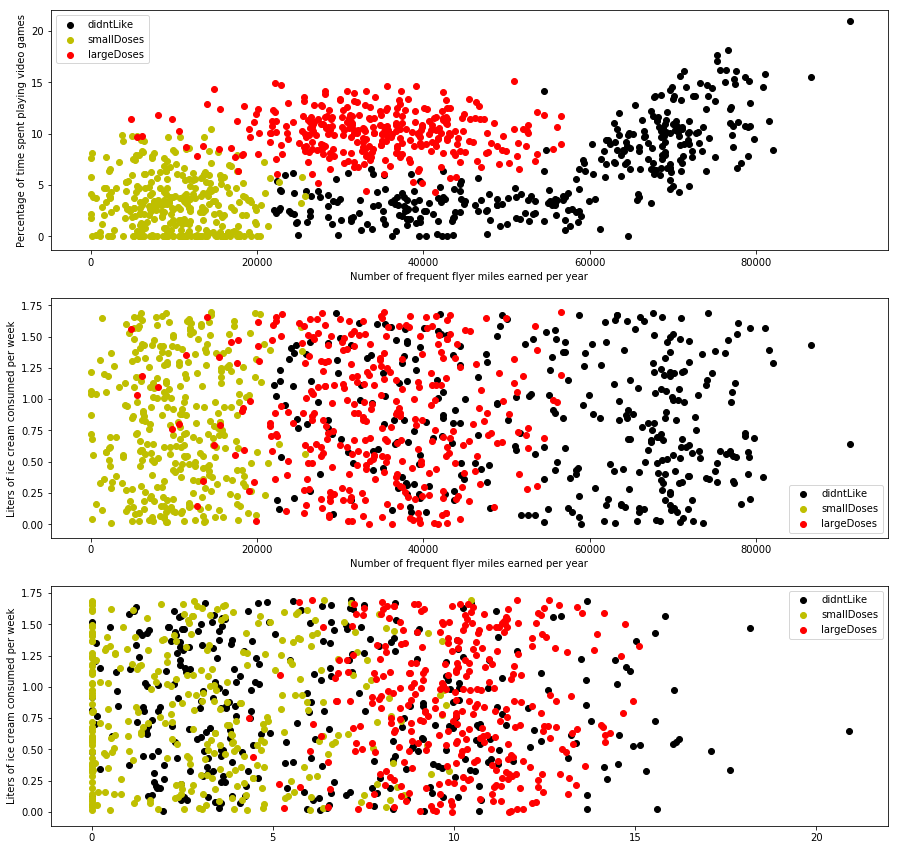

```python
if __name__ == '__main__':
    filename = "kNN_Dating/datingTestSet.txt"
    datingDataMat, datingLabels = file2matrix(filename) # 打开文件 处理文件数据
    showdatas(datingDataMat, datingLabels) # 对数据进行绘图
```